# Training Questions

Rollan Geronimo

12/14/2021

# 1 Fishing Inspection Questions

## 1.1 Fishing track and points plot

**1. We may also want to know about fishing. Plot a map of the track and fishing points by the vessel with the MMSI 367650000 between March 1 2017 and March 5 2017. Are there any issues with the track?**

There are tracks labelled as apparent fishing but looks like non-fishing (e.g., cruising / transiting) patterns.

```r
ssvid = '367650000'
dateRange <- c("2017-03-01","2017-03-05")

# ssvid = '417000121'
# dateRange <- c("2020-01-01", "2020-12-31")
query_Tracks <- glue::glue(
  " SELECT
    ssvid,
    seg_id,
    lon,
    lat,
    hours,
    timestamp,
    nnet_score
    FROM
    `gfw_research.pipe_v20201001_fishing`
    WHERE seg_id IN (
      SELECT seg_id
      FROM `gfw_research.pipe_v20201001_segs`
      WHERE
      overlapping_and_short IS FALSE AND
      good_seg IS TRUE) AND
    ssvid = '{ssvid}' AND
    _partitiontime >= TIMESTAMP('{dateRange[1]}') AND
    _partitiontime <= TIMESTAMP('{dateRange[2]}') AND
    # Should we include nnet_scores that are NULL?
    nnet_score IS NOT NULL
    ORDER BY timestamp"
)

vTracks <- gfw_query(query = query_Tracks,
                          run_query = TRUE,
                          con = con)$data
```

```
## [1] "Running query..."
```

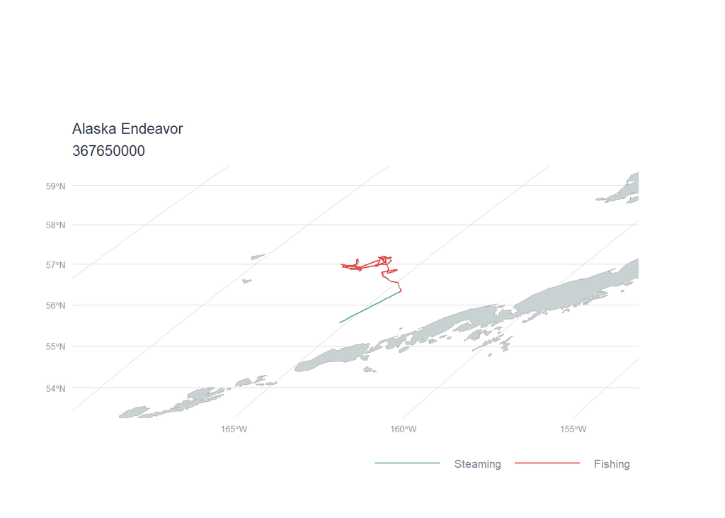

```
##
## $bbox
## $bbox$box_in
##       xmin       ymin       xmax       ymax
## -169.39678   53.56555 -162.53903   59.20273
##
## $bbox$box_out
##      xmin      ymin      xmax      ymax
## -13001845   6337001 -11836591   6854891
##
## $bbox$out_crs
## [1] "+proj=eqearth +datum=WGS84 +wktext"
```

```r
plot_vessel_track_fish(
  vTracks,
  bounding_box_man = NA,
  color_fishing = TRUE,
  color_by = "nnet_score",
  map_res = 10,
  theme = "light",
  buffer = 2,
  add_gridlines = TRUE,
  gfw_proj_name = "Equal Earth",
  vessel_name = "Alaska Endeavor" # name obtained by searching for the MMSI in the GFW map
)
```

```r
# # This is another way to plot the tracks
# land_sf <- rnaturalearth::ne_countries(scale = 10, returnclass = 'sf')
# plot_vessel_track(
#   vTracks,
#   lat = "lat",
#   lon = "lon",
#   show_fishing = TRUE,
#   spatial = TRUE
# )
```

**2. How many hours of fishing are estimated during this time? Is it different if you use the `pipe_production_v20201001.proto_events_fishing` table?**

The proto_events_fishing table will give a slightly restrictive fishing (based on consistency and duration filter).

```r
q_events <- glue::glue(
  " SELECT
    SUM(IF(event_type = 'fishing',
     TIMESTAMP_DIFF(event_end, event_start, MINUTE),
     0))/60 AS fishing_hours
    FROM
    `pipe_production_v20201001.proto_events_fishing`
    WHERE
    event_start BETWEEN TIMESTAMP('{dateRange[1]}') AND TIMESTAMP('{dateRange[2]}')
    AND
    seg_id LIKE '{ssvid}-%' # But seg_id does not always rely only on ssvid. It can sometimes be imo.
    "
) # better to get the seg_id and match with the seg_id in the proto table

# "Fishing hours" not exactly interpreted as gear-in-the-water time but more broadly in terms of vessel behavior that appears as fishing operations.
# GFW map now uses proto_fishing_events instead of pipe_fishing
# Can use proto_fishing_events for single vessel analysis
# Use fishing days but put note on what is counted as 'fishing day'
# JSON_EXTRACT_SCALAR(event_vessels,"$[0].ssvid") as ssvid

events_hours <- gfw_query(query = q_events,
                          run_query = TRUE,
                          con = con)$data
```

```
## [1] "Running query..."
```

**3. What type of fishing vessel is it?**

```r
q_vesselClass <- glue::glue(
  "SELECT
    year,
    inferred.inferred_vessel_class AS inferred_class,
    registry_info.best_known_vessel_class AS registry_class,
    best.best_vessel_class AS best_class
  FROM `world-fishing-827.gfw_research.vi_ssvid_byyear_v20210706`
  WHERE ssvid = '{ssvid}' AND year = 2017
   "
)

v_class <- gfw_query(query = q_vesselClass,
                          run_query = TRUE,
                          con = con)$data
```

```
## [1] "Running query..."
```

Best vessel class = trawlers.

**4. Provide the other vessel identity information and registry records during this time.**

The vessel identity information can be derived from the vessel_database.all_vessels_v20210701. Registry information is in the vessel info table vi_ssvid_byyear (since we need to get the registry info for the given period).

What is the difference between “normalized” and non-normalized values in the *vi_ssvid_byyear* table?

```r
q_vesselInfo <- glue::glue(
  "SELECT
     ssvid,
     year,
     registry_info.best_known_shipname,
     ais_identity.callsign,
     ais_identity.imo,
     ais_identity.shiptype,
     ais_identity.flag_mmsi,
     inferred.inferred_vessel_class,
     inferred.inferred_vessel_class_score_byyear,
     registry_info.registries_listed,
     registry_info.best_known_flag,
     registry_info.best_known_callsign,
     registry_info.best_known_imo,
     registry_info.best_known_vessel_class,
     registry_info.best_known_length_m,
     registry_info.best_known_tonnage_gt,
     registry_info.best_known_engine_power_kw,
     registry_info.best_known_crew_size,
     best.registry_net_disagreement
  FROM `world-fishing-827.gfw_research.vi_ssvid_byyear_v20210913`
  WHERE ssvid = '{ssvid}' AND year = 2017
   "
)

v_info <- gfw_query(query = q_vesselInfo,
                          run_query = TRUE,
                          con = con)$data
```

```
## [1] "Running query..."
```

```r
v_info %>% t() %>% data.frame() %>% rownames_to_column(var="parameters") %>% rename(values = '.') %>%
  gt() %>%
  tab_style(
    style = cell_text(color = "black", weight = "bold"),
    locations = list(
      cells_row_groups(),
      cells_column_labels(everything())
    )
  ) %>%
  cols_label(
    parameters = "Parameters",
    values = "Values"
  )
```

| Parameters | Values |
| --- | --- |
| ssvid | 367650000 |
| year | 2017 |
| best_known_shipname | ALASKAENDEAVOR |
| callsign | c("7DF7174", "WDF7174"), c(1, 21762) |
| imo | c("792797470", "793355550"), c(1, 21762) |
| shiptype | Fishing, 21763 |
| flag_mmsi | USA |
| inferred_vessel_class | trawlers |
| inferred_vessel_class_score_byyear | 0.9999972 |
| registries_listed | NEPAC, REV, USA |
| best_known_flag | USA |
| best_known_callsign | WDF7174 |
| best_known_imo | 7933555 |
| best_known_vessel_class | trawlers |
| best_known_length_m | 35.73171 |
| best_known_tonnage_gt | NA |
| best_known_engine_power_kw | 132 |
| best_known_crew_size | NA |
| registry_net_disagreement | NA |

**5. Let’s take the scale up for a second. Plot a raster of all fishing by Chinese flagged squid jiggers vessels in NPFC in 2018. What are some caveats to take into consideration with this data?**

```r
q_effort <- glue::glue(
  "WITH
positions AS (
          SELECT
          ssvid,
          lat,
          lon,
          nnet_score,
          night_loitering,
          hours
          FROM `world-fishing-827.gfw_research.pipe_v20201001_fishing`,
          UNNEST(regions.rfmo) rfmo
          WHERE EXTRACT(DATE FROM _PARTITIONTIME) BETWEEN ('2018-01-01') AND ('2018-12-31')
              AND seg_id IN (
                  SELECT seg_id
                  FROM `world-fishing-827.gfw_research.pipe_v20201001_segs`
                  WHERE good_seg
                  AND NOT overlapping_and_short
              )
              AND rfmo = 'NPFC'
      ),

fishing_vessels AS (
          SELECT
              ssvid,
              year,
              best_vessel_class AS geartype,
              best_flag as flag
          FROM `world-fishing-827.gfw_research.fishing_vessels_ssvid_v20210913`
          WHERE year = 2018
          AND best_flag = 'CHN'
          AND best_vessel_class = 'squid_jigger'
      ),

positions_vi AS (
    SELECT * EXCEPT(nnet_score, night_loitering),
        IF(b.geartype = 'squid_jigger', night_loitering, nnet_score) as nnet_score
    FROM positions a
    LEFT JOIN fishing_vessels b
    USING (ssvid)
),

grouped AS (
    SELECT
        FLOOR(lat * 10)/10 as lat_bin,
        FLOOR(lon * 10)/10 as lon_bin,
        SUM(IF(nnet_score > 0.5, hours, 0) ) AS fishing_hours
    FROM positions_vi
    GROUP BY 1,2
)

SELECT * FROM grouped
   "
)

fishing_effort <- gfw_query(query = q_effort,
                          run_query = TRUE,
                          con = con)$data
```

```
## [1] "Running query..."
```

```
## Spherical geometry (s2) switched off
```

[figure not shown]

```r
fishing_effort %>% filter(fishing_hours>1) %>%
    ggplot() +
    geom_raster(aes(x = lon_bin,
                    y = lat_bin,
                    fill = fishing_hours)) +
    geom_gfw_eez(center = 160) +
    geom_gfw_land(center = 160) +
    #coord_sf(crs = CRS('+proj=longlat +datum=WGS84'), expand=F)+
#    lims(x = lonRange, y = latRange) +
    scale_fill_gradientn(colors = gfw_palette('map_effort_dark'),
                         limits = c(0,500),
                         oob = scales::squish,
                         na.value = NA) +
    labs(fill = 'Fishing hours') +
    theme_gfw_map() +
    theme(axis.text = element_text(family = "Roboto", color = "#848b9b",
              size = 10),
          legend.text = element_text(family = "Roboto",
              color = "#848b9b", size = 10), legend.title = element_text(family = "Roboto Bold",
              color = "#363c4c", size = 10), plot.title = element_text(family = "Roboto Bold",
              color = "#363c4c", size = 12), plot.subtitle = element_text(family = "Roboto",
              color = "#363c4c", size = 12)
          )
```